# colouR

[figure not shown]

# Introduction to the colouR Package

Welcome to the `colouR` package, a useful tool for analyzing and utilizing the colors in images, as well as providing color palettes inspired by Radiohead and Taylor Swift album covers. Whether you are a designer looking for inspiration, a data analyst searching for unique ways to visualize data, or a music lover wanting to incorporate your favorite album colors into your projects, this package is for you. It is recommended to view this instructional guide via the GitHub page: https://alaninglis.github.io/colouR/articles/colouR.html

## Package Overview

The `colouR` package provides a set of functions that allows you to:

- Extract color values from an image (either JPG or PNG).
- Obtain the top $n$ colors in the image based on their frequency.
- Group and average colors in the image.
- Utilize color palettes inspired by Radiohead and Taylor Swift album covers.
- These functionalities make the `colouR` package a versatile and easy-to-use tool for exploring and working with colors in images.

## Key Functions

Some of the main functions included in the `colouR` package are:

- `getTopCol()`: Extracts the top n colors from an image, with options to exclude black and white shades, and to group and average colors.
- `colPalette()`: Creates a color palette based on a specified album cover from either Radiohead or Taylor Swift discography.
- `scaleColor()`: Provides a ggplot2-compatible color scale based on the selected album cover palette, for both discrete and continuous data.
- `scaleFill()`: Provides a ggplot2-compatible fill scale based on the selected album cover palette, for both discrete and continuous data.
- `groupCols`: This function takes a vector of hex color values and groups them using k-means clustering in the RGB color space.
- `avgHex`: This function takes a data frame with two columns: one for the hex color values and another for the group labels. It calculates the average color for each group and returns a data frame with the group labels and their corresponding average hex colors.
- `img2pal`: Creates a Colour Palette from an input image.
- `plotPalette`: This function takes a data frame with a column of colors and plots the colors as a color palette.

In addition, we provide several utility functions, all of which are demonstrated in this document.

## Getting Started

To begin using the `colouR` package, simply install it from GitHub, load it into your R session, and start exploring the world of colors in images.

```r
# install.packages("devtools")
#devtools::install_github("AlanInglis/colouR")

# Load the package
library(colouR)

# Load ggplot2 for making some plots
library(ggplot2)
```

# Get the top n colours in an image

The first function we demonstrate is the `getTopCol` function. This function reads an image file, extracts the colors, and returns the top n colors based on their frequency in the image. Optionally, black and white shades can be excluded, and the colors can be grouped and averaged (more on colour averaging later!). This function can take in a .jpg, .jpeg, or .png or a url pointing to an image using any of these formats, via the `path` argument and returns the top `n` colours used in the image.

## Function Arguments

The arguments for this function are:

- `path` Character, the path to the image file (either jpg or png).
- `n` Integer, the number of top colors to return. If NULL (default), return all colors.
- `exclude` Logical, whether to exclude black and white shades. Default is TRUE.
- `sig` Integer, the number of decimal places for the color percentage. Default is 4.
- `avgCols` Logical, whether to average the colors by groups. Default is TRUE.
- `n_clusters` Integer, the number of clusters to use for grouping colors. Default is 5.
- `customExclude` Character vector. Optional vector of custom color codes in HEX format to be excluded.

## Input Image

To begin, lets first take a look at a raw image:

[figure not shown]

Figure 1: The *“towering inferno of physical perfection”* that is Bender.

```r
knitr::include_graphics("https://raw.githubusercontent.com/AlanInglis/colouR/master/images/bender.png")
```

## Top 10 colours in image

In the code below we obtain the top 10 most frequent colours used in the image without using any colour grouping or averaging by setting `avgCols = FALSE`. Additionally, we chose not to exclude any black or white shades by setting `exclude = FALSE` (note: the `exclude` argument excludes many black and white shades, however this list is far from exhaustive and, consequently, blacks and white will most likely still be included. However we do allow you to provide additional black and white hex codes to be included in the exclude function… more on that below). The output of the `getTopCols` when setting the outlined parameters is a data frame with three columns, that is, the top colors, their frequency, and percentage in the image.

```r
set.seed(1701) # for reproducability

top10 <- getTopCol(path = "https://raw.githubusercontent.com/AlanInglis/colouR/master/images/bender.png",
                   n = 10,
                   avgCols = FALSE,
                   exclude = FALSE)

# take a look at the top 100 most frequent colours in the image:
top10
```

```
#>        hex    freq col_percent
#> 1  #FFFFFF 1984612     54.1233
#> 2  #A9C5DA  487309     13.2896
#> 3  #7CA5C1  160750      4.3839
#> 4  #C9E0F0   60288      1.6441
#> 5  #5A8595   36473      0.9947
#> 6  #FFFAC2   36049      0.9831
#> 7  #231F20   11566      0.3154
#> 8  #A9C5DB    8923      0.2433
#> 9  #AAC5DA    7807      0.2129
#> 10 #7BA4C0    6042      0.1648
```

## Plot top 10 colours

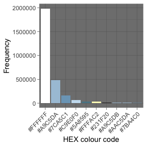

Figure 2: Frequency of colours used in the image. We can see that white dominates the image.

```r
# order factors
top10$hex <- factor(top10$hex, levels = top10$hex)

# plot
ggplot(top10, aes(x = hex, y = freq)) +
  geom_bar(stat = 'identity', fill = top10$hex) +
  theme_dark() +
  theme(axis.text.x = element_text(angle = 45, hjust = 1)) +
  xlab('HEX colour code') +
  ylab('Frequency')
```

## Exclude unwanted colours

Since most of this white is probably from the background of the image, this result is not very useful. To exclude white and black shades we set `exclude = TRUE` (more on this below).

```r
set.seed(1701) # for reproducability

top10exclude <- getTopCol(path = "https://raw.githubusercontent.com/AlanInglis/colouR/master/images/bender.png",
                          n = 10,
                          avgCols = FALSE,
                          exclude = TRUE,
                          customExclude = NULL)
```

Now, plotting these colours gives a more truer representation of the colours used in the image:

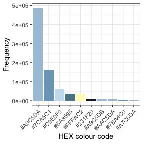

Figure 3: Frequency of colours used in the image with white and black colours excluded.

```r
# order factors
top10exclude$hex <- factor(top10exclude$hex, levels = top10exclude$hex)

# plot
ggplot(top10exclude, aes(x = hex, y = freq)) +
  geom_bar(stat = 'identity', fill = top10exclude$hex) +
  theme_bw() +
  theme(axis.text.x = element_text(angle = 45, hjust = 1)) +
  xlab('HEX colour code') +
  ylab('Frequency')
```

## Average top colours

In Figure 3, we can see that there are a lot of similar colours. That is, many of the colours are different shades of a metallic blue. By setting `avgCols = TRUE`, we can group together colours with similar shades into $n$ groups via the `n_clusters` argument and average over them to produce a single colour. In this case, we are setting `n_clusters = 5` (this eliminates the need to set the `n` argument).

```r
set.seed(1701) # for reproducability

top10avg <- getTopCol(path = "https://raw.githubusercontent.com/AlanInglis/colouR/master/images/bender.png",
                      avgCols = TRUE,
                      exclude = TRUE,
                      n_clusters = 5)
```

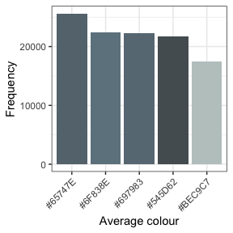

Figure 4: Frequency of averaged colours used in the image with white and black colours excluded.

```r
# order factors
top10avg$avg_color <- factor(top10avg$avg_color, levels = top10avg$avg_color)

# plot
ggplot(top10avg, aes(x = avg_color, y = freq)) +
  geom_bar(stat = 'identity', fill = top10avg$avg_color) +
  theme_bw() +
  theme(axis.text.x = element_text(angle = 45, hjust = 1)) +
  xlab('Average colour') +
  ylab('Frequency')
```

# Excude custom colours

```r
top10exclude
```

```
#>        hex   freq col_percent
#> 2  #A9C5DA 487309     13.2896
#> 3  #7CA5C1 160750      4.3839
#> 4  #C9E0F0  60288      1.6441
#> 5  #5A8595  36473      0.9947
#> 6  #FFFAC2  36049      0.9831
#> 7  #231F20  11566      0.3154
#> 8  #A9C5DB   8923      0.2433
#> 9  #AAC5DA   7807      0.2129
#> 10 #7BA4C0   6042      0.1648
#> 11 #A7C6DA   5520      0.1505
```

However, if we want to exclude any of these colours, we can pass them as a character vector of hex values to the `customExclude` argument, as follows:

```r
coloursToExclude <- c("#A9C5DA", "#7CA5C1", "#C9E0F0", "#5A8595", "#FFFAC2")

top10exclude <- getTopCol(path = "https://raw.githubusercontent.com/AlanInglis/colouR/master/images/bender.png",
                          n = 10,
                          avgCols = FALSE,
                          exclude = TRUE,
                          customExclude = coloursToExclude)
```

Now when we look at the `top10exclude` object, it should not contain any of the colours selected.

```r
top10exclude
```

```
#>        hex  freq col_percent
#> 7  #231F20 11566      0.3154
#> 8  #A9C5DB  8923      0.2433
#> 9  #AAC5DA  7807      0.2129
#> 10 #7BA4C0  6042      0.1648
#> 11 #A7C6DA  5520      0.1505
#> 12 #A7C6DB  5496      0.1499
#> 13 #7AA6C1  4933      0.1345
#> 14 #AAC5D8  4731      0.1290
#> 15 #7AA6C3  4524      0.1234
#> 16 #A8C4D9  4467      0.1218
```

# Grouping colours

As we have already seen, in `colouR` we provide an option to group and average colours in the `getTopCol` function. The function used to group the colours is the `groupCols` function. This function takes a vector of hex color values and converts them to the RGB colour space. It then groups them into `n_clusters` using k-means clustering. For example, if we take a vector of colours like the one below, we can see that there are some unique colours and some colours that are similar. To begin, lets take a look at the colour palette, we can do this by using the `plotPalette` function:

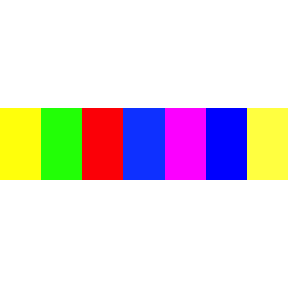

Figure 5: Colour palette.

```r
hex_colors <- c("#FF0000", "#00FF00", "#0000FF", "#FFFF00", "#FF00FF", "#1050FF", "#ffff50")

plotPalette(hex_colors)
```

To group the colours into, say, 4 groups we set `n_clusters = 4`. The output is a data frame with two columns. One containing the hex value and another containing the group number.

```r
cols <- c("#FF0000", "#00FF00", "#0000FF", "#FFFF00", "#FF00FF", "#1050FF", "#ffff50")

set.seed(1701) # for reproducability
grCol <- groupCols(hex_colors = cols, n_clusters = 4)
```

## Plot Groups

Arranging the data frame by group and plotting gives us:

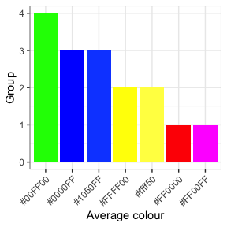

Figure 6: Grouped colours.

```r
# order factors
grCol$hex_color <- factor(grCol$hex_color, levels = grCol$hex_color)

# plot
ggplot(grCol, aes(x = hex_color, y = group)) +
  geom_bar(stat = 'identity', fill = grCol$hex_color) +
  theme_bw() +
  theme(axis.text.x = element_text(angle = 45, hjust = 1)) +
  xlab('Average colour') +
  ylab('Group')
```

or using the `plotPalette` function:

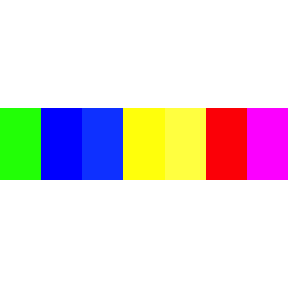

Figure 7: Grouped colour palette.

```r
plotPalette(df = grCol, color_col = 'hex_color')
```

We can see that the green colour is in a single group, the two blue colours are grouped together, along with the two yellow colours. The red and violet colours are also in a group.

# Average colours

The `avgHex` function takes a data frame with two columns: one for the hex color values and another for the group labels. It calculates the average color for each group and returns a data frame with the group labels and their corresponding average hex colors. Using the grouped colours from before we get:

```r
set.seed(1701)
avgCl <- avgHex(df = grCol, group_col = 'group', hex_col = 'hex_color')
avgCl
```

```
#>   group avg_color freq
#> 1     1   #FF007F    2
#> 2     2   #FFFF28    2
#> 3     3   #0828FF    2
#> 4     4   #00FF00    1
```

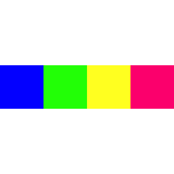

Figure 8: Averaged colour palette.

```r
plotPalette(df = avgCl, color_col = 'avg_color')
```

In Figure 8, we can see that the four groups have been averaged into single colours.

# Build Colour Palette from Image

The `img2pal` function automates some of the above processes and creates a custom palette, ready to use, directly from an input image. The function arguments mirror those from the `gettpCol` function. In the example below, we are creating a colour palette of the top 10 most frequent colours, while grouping into 15 clusters and averaging the colours. Using the same image of Bender from above, we can do the following:

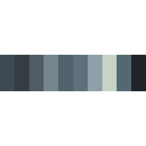

Figure 9: Colour palette created directly from input image.

```r
pal <- img2pal(path = "https://raw.githubusercontent.com/AlanInglis/colouR/master/images/bender.png",
               n = 10,
               avgCols = TRUE,
               exclude = TRUE,
               n_clusters = 15,
               customExclude = NULL)
```

And we can take a look at the hex codes for the colour palette by checking the newly created `pal`opbject:

```r
pal
```

```
#>  [1] "#8898A0" "#64747F" "#D3DAD1" "#2A2F34" "#434E56" "#A0AFB8" "#667B86"
#>  [8] "#4D5C64" "#71838D" "#636F78"
```

# Prebuilt Palettes

One useful feature of taking in an image and return the top $n$ colours is the ability to turn that image into a colour palette. For fun, we provide colour palettes based on all the studio albums of both Radiohead and Taylor Swift. The palettes can be accessed by indexing either `radiohead_palettes` or `taylor_palettes`, as shown in the code below. It should be noted, that when creating these custom palettes, the top 10 average colours were chosen.

## Radiohead

The full list of names for Radiohead are:

- `pabloHoney`: Pablo Honey
- `Bends` : The Bends
- `okComputer`: OK Computer
- `KID_A` : Kid A
- `Amnesiac` : Amnesiac
- `httt` : Hail to the Theif
- `inRainbows`: In Rainbows
- `tkol` : The King of Limbs
- `amsp` : A Moon Shaped Pool

## Taylor Swift

The full list of names for Taylor Swift are:

- `tSwift` : Taylor Swift
- `fearless` : Fearless
- `speakNow` : Speak Now
- `red` : Red
- `1989` : 1989
- `reputation`: Reputation
- `lover` : Lover
- `folklore` : Folklore
- `evermore` : Evermore
- `midnights` : Midnights

```r
radiohead_palettes$pabloHoney
```

```
#>  [1] "#D9BE9C" "#C8751E" "#2C2372" "#EAE1D5" "#E8B559" "#7E8B42" "#39251A"
#>  [8] "#EAA41C" "#D7478C" "#A7381F"
```

```r
taylor_palettes$red
```

```
#>  [1] "#694B4B" "#C0B6A4" "#4E3843" "#7F675A" "#AB5862" "#95806D" "#9B2E47"
#>  [8] "#A99783" "#EDE6DA" "#30263A"
```

## Palette Plots

To view any of the palettes, we can use the `plotPalette` function:

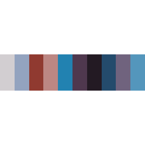

Figure 10: Radiohead OK Computer colour palette.

```r
plotPalette(radiohead_palettes$okComputer)
```

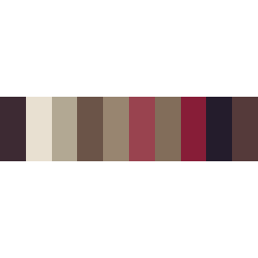

Figure 11: Taylor Swift Red colour palette.

```r
plotPalette(taylor_palettes$red)
```

Additionally, to create a larger colour palette we provide the `colPalette` function. This function generates a custom color palette based on the specified `palette` name. The color palettes are sourced from two predefined lists: `taylor_palettes` and `radiohead_palettes`. For example

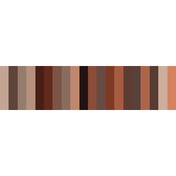

```r
# Create a color palette based on a Taylor Swift album cover
tswift_palette <- colPalette(palette = "evermore")
tpal <- tswift_palette(20)
plotPalette(tpal)
```

# Use in ggplot

For convenience, we also provide functionality to use these palettes as either a scale fill or scale colour (similar to the `ggplot2` `scale_color` and `scale_fill` functions).

```r
library(dplyr)
```

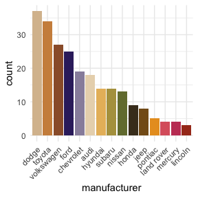

Figure 13: Displaying data using a Radiohead colour palette and `scaleFill`.

```r
# Apply a Radiohead color scale to a ggplot2 plot

# Create a summary data frame with counts per manufacturer for the mpg data
manufacturer_counts <- mpg %>%
  group_by(manufacturer) %>%
  summarize(count = n())

# sort the data
mpgsort <- manufacturer_counts[order(manufacturer_counts$count, decreasing = TRUE), ]

# order factors
mpgsort$manufacturer <-  factor(mpgsort$manufacturer, levels = mpgsort$manufacturer)

# Create the plot using a Radiohead palette
ggplot(mpgsort, aes(x = manufacturer, y= count, fill = manufacturer)) +
  geom_bar(stat = 'identity') +
  theme_minimal() +
  theme(axis.text.x = element_text(angle = 45, hjust = 1)) +
  scaleFill(palette = "pabloHoney", guide = "none")
```

To do the same using a Taylor Swift palette:

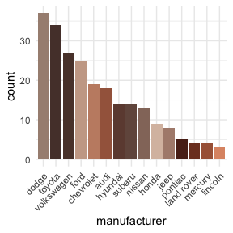

Figure 14: Displaying data using a Taylor Swift colour palette and `scaleFill`.

```r
# Create the plot using a Taylor Swift palette
ggplot(mpgsort, aes(x = manufacturer, y= count, fill = manufacturer)) +
  geom_bar(stat = 'identity') +
  theme_minimal() +
  theme(axis.text.x = element_text(angle = 45, hjust = 1)) +
  scaleFill(palette = "evermore", guide = "none")
```

Similarly, to use `scaleColor`:

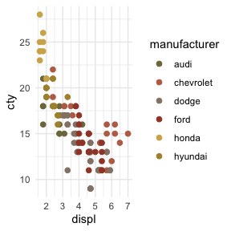

Figure 15: Displaying data using a Radiohead colour palette and `scaleColor`.

```r
# Create the plot using a Radiohead palette
ggplot(mpg[1:122,],  aes(x = displ, y = cty, color = manufacturer)) +
  geom_point(size = 2) +
  scaleColor(palette = 'tkol') +
  theme_minimal()
```

And using a Taylor Swift palette:

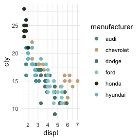

Figure 16: Displaying data using a Taylor Swift colour palette and `scaleColor`.

```r
# Create the plot using a Taylor Swift palette
ggplot(mpg[1:122,],  aes(x = displ, y = cty, color = manufacturer)) +
  geom_point(size = 2) +
  scaleColor(palette = 'tSwift') +
  theme_minimal()
```

Of course, we can use these palettes in a more *traditional* way by passing the palette to ggplot. For example:

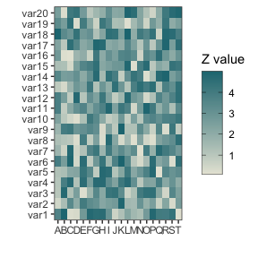

Figure 17: Heatmap displaying data using a Taylor Swift colour palette.

```r
# Dummy data
x <- LETTERS[1:20]
y <- paste0("var", seq(1,20))
data <- expand.grid(X=x, Y=y)
data$Z <- runif(400, 0, 5)

# Set a Taylor Swift palette of two colours
pal <- taylor_palettes$tSwift[c(6,5)]

# Create a heatmap
ggplot(data, aes(x = X, y = Y)) +
  geom_tile(aes(fill = Z)) +
  scale_fill_gradientn(
    colors = pal,  name = "Z value",
    guide = guide_colorbar(
      order = 1,
      frame.colour = "black",
      ticks.colour = "black"
    ), oob = scales::squish
  ) +
  xlab('') + ylab('') +
  theme_bw()
```

# Utility Functions

In this section we take a brief look at some of the utility functions used in `colouR`. Thes include a useful little function that returns the file extension of a given file. For example:

```r
fileName <- "https://raw.githubusercontent.com/AlanInglis/colouR/master/images/bender.png"
getExtension(file = fileName)
```

```
#> [1] "png"
```

```r
# another example
getExtension(file = "example.txt")
```

```
#> [1] "txt"
```

We can see that the returned values are .png and .txt, respectivley.

Additionally, we provide a function that reads an image file (PNG or JPG) from a URL and returns the image data. This is done via the `read_image_from_url` function. It returns an object containing the image data. If the image is a JPG, the object will be of class “array”. If the image is a PNG, the object will be of class “matrix”.

Using the image of Bender from before we can get the image data. The resulting object can then be used, for example:

[figure not shown]

Figure 18: Reading in an image from a url.

```r
urlName <- "https://raw.githubusercontent.com/AlanInglis/colouR/master/images/bender.png"
image <- read_image_from_url(path = urlName)

# set up a plot
plot(c(100, 250), c(300, 550), type = "n", xlab = "", ylab = "")
rasterImage(image,100,300,150,550)
```